# 210b_lab5

# forced linebreak

### 1) Climate Change - Elevational Distribution Change

**As the world warms, the geographic ranges of species might shift toward cooler areas. Chen et al. (2011) studied recent changes in the highest elevation at which species occur. Typically, higher elevations are cooler than lower elevations. Below are the changes in the highest elevation for 31 taxa, in meters, over the late 1900s and early 2000s. Positive numbers indicate upward shifts in elevation, and negative numbers indicate shifts to lower elevations.**

```r
elev_change <- c(58.9, 7.8, 108.6, 44.8, 11.1, 19.2, 61.9, 30.5, 12.7, 35.8, 7.4, 39.3, 24.0, 62.1, 24.3, 55.3, 32.7, 65.3, -19.3, 7.6, -5.2, -2.1, 31.0, 69.0, 88.6, 39.5, 20.7, 89.0, 69.0, 64.9, 64.8)
```

#### a) What is the sample size n?

The sample size is **31**.

#### b) What is the mean of the data points?

```r
elev_change_mean <- mean(elev_change)
```

The mean is **39.3290323 m**.

#### c) What is the standard deviation of elevational range shift?

```r
elev_change_std <- sd(elev_change)
```

The standard deviation is **30.6631178 m**.

#### d) What is the standard error of the mean for these data?

```r
elev_change_sterr <- elev_change_std/sqrt(length(elev_change))
```

The standard error is **5.5072585 m**.

#### e) How many degrees of freedom will be associated with a confidence interval and a one-sample t-test for the mean elevation shift?

```r
# df is one less than n because we have to estimate the stdev from the sample
elev_change_df <- length(elev_change) - 1
```

This process will have **30** degrees of freedom.

#### f) What values of $\alpha$ is needed for a 95% confidence interval?

For a 95% confidence interval we have $\alpha$ = 0.05, which is split into two $\alpha/2=0.025$ chunks on either extreme end of the interval.

#### g) What is the critical value of t for this $\alpha$ and number of degrees of freedom?

```r
elev_t_crit <- qt(0.975, elev_change_df)
```

This confidence interval / df combination will have a critical t value of **2.0422725**.

#### h) What assumptions are necessary to use the confidence interval calculations?

1. We have a random sample from the population of specific elevation changes.
2. The actual distribution of elevation change values is normally distributed.

#### i) Calculate the 95% confidence interval for the mean using these data.

```r
spread_95 <- qt(0.975, df=elev_change_df) * elev_change_std/sqrt(length(elev_change))

elev_change_lower <- elev_change_mean - spread_95
elev_change_upper <- elev_change_mean + spread_95
```

A 95% confidence interval for the true mean change in upper elevation limit across montane species is given by:

**28.082 m $<\mu_{elev\_change} <$ 50.576 m**

#### j) For the one-sample t-test, write the appropriate null and alternative hypotheses.

$H_o:$ There is no significant change in upper elevation limit across species.

$H_a:$ There is a significant change in upper elevation limit across species.

#### k) Calculate the test statistic t for this test.

```r
elev_test <- t.test(elev_change)
```

I ran a one-sample t-test and found *t*(*df*=30) = 7.1413085, *p-value* = 6.06e-08

#### l) What assumptions are necessary to do a one-sample t-test?

They’re the same as for the confidence interval:

1. We have a random sample from the population of specific elevation changes.
2. The actual distribution of elevation change values is normally distributed.

#### m) Describe the P-value for this test.

The p-value we returned above is VERY LOW (6.06e-08).

#### n) Did species change their highest elevation on average?

Because the p-value we got is VERY LOW, we can reject the null hypothesis that there was no overall change in maximum elevation across species. There does appear to have been a change in upper elevation limits.

### 2) A tolerable level of a certain pollutant is 16 mg/l. A researcher takes a sample of size n = 50, and finds that the mean level of the pollutant is 18.5 mg/l, with a standard deviation of 7 mg/l. Construct a 95% confidence interval around the same mean, and determine whether the tolerable level is within this interval.

Because the sample size is relatively small, we’ll use a t distribution.

```r
n_poll = 50
mean_poll = 18.5
std_poll = 7

spread_95 <- qt(0.975, df=n_poll-1) * std_poll/sqrt(n_poll)

poll_change_lower <- mean_poll - spread_95
poll_change_upper <- mean_poll + spread_95
```

A 95% confidence interval for the true mean value of pollutant (in mg/L) in the water is given by:

**16.511 mg/L $<\mu_{pollutant} <$ 20.489 mg/L**

This range **DOES NOT INCLUDE** the ‘tolerable’ level guideline of 16 mg/L, so we can conclude that the pollution levels here are not tolerable.

### 3) Refer back to problem 1. Using the same data, calculate the 95% confidence interval for the variance using the following steps.

#### a) What does the confidence interval refer to — the sample variance or the population variance?

The confidence interval attempts to use information from the sample variance to make claims about the population variance. The interval given is a projection about the values of the population variance.

#### b) What assumptions are necessary for construction of the confidence interval for variance?

1. The data must be a random sample of the actual population
2. The true population variable must be normally distributed.

#### c) What is the sample variance of these data?

```r
elev_var <- var(elev_change)
```

The sample variance is **940.2267957 $m^2$**.

#### d) How many degrees of freedom are associated with these data for estimates of variance?

As before, the number of degrees of freedom is **30**.

#### e) What is for this analysis?

As before, the $\alpha$ value is 0.05, which is split into two $\alpha/2=0.025$ chunks for a two-sided 95% confidence interval.

#### f) Find the critical value of $\chi^2$ for $\alpha/2$?

```r
elev_critical_chi_hi = qchisq(0.025, df=elev_change_df)
```

**$\chi^2(df=$ 30 $,1-\frac{\alpha}{2}=0.025) =$ 16.7907723**

#### g) What is the critical value of $\chi^2$ for $1-\alpha/2$?

```r
elev_critical_chi_low = qchisq(0.975, df=elev_change_df)
```

**$\chi^2(df=$ 30 $,\frac{\alpha}{2}=0.025) =$ 46.9792422`**

#### h) Calculate the 95% confidence interval for the variance of the elevational range shift.

$$\frac{(n-1)s^2}{\chi^2_{\alpha/2}} < \sigma^2 < \frac{(n-1)s^2}{\chi^2_{1-\alpha/2}}$$

```r
elev_var_low <- (length(elev_change)-1) * elev_change_std^2 / elev_critical_chi_low
elev_var_hi <- (length(elev_change)-1) * elev_change_std^2 / elev_critical_chi_hi
```

A 95% confidence interval for the true variance of the change in upper elevation limit across montane species is given by:

**600.41 $m^2$ $<\sigma^2_{elev\_change} <$ 1679.899 $m^2$**

### 4) Measurements of the distance between the canine tooth and last molar for 35 wolf upper jaws were made by researchers. They found the 95% confidence interval for the mean to be 10.17 cm < $\mu$ < 10.47 cm and the 99% confidence interval to be 10.21 cm < $\mu$ < 10.44 cm. Without seeing the data, explain why they must have made a mistake.

The 99% confidence should actually be WIDER than the 95% confidence interval, because it contains a larger percentage of the distribution. Their 99% confidence interval was reported as narrower than the 95% one, which doesn’t make sense.

### 5) Here are the data on wolf upper jaws from previous problem in cm. There are 35 individuals in this data set. Assume that this variable is normally distributed.

```r
wolf_jaws <- data.frame(length=c(10.2, 10.4, 9.9, 10.7, 10.3, 9.7, 10.3, 10.7, 10.1, 10.6, 10.3, 10.0, 10.2, 10.1, 10.3, 9.9, 9.7, 10.6, 10.4, 10.1, 10.6, 10.3, 10.3, 10.5, 10.2, 10.2, 10.5, 10.1, 11.2, 10.5, 10.3, 10.0, 10.3, 10.7, 11.1))
```

#### a. Plot the histogram to confirm that frequency distribution is roughly bell shaped.

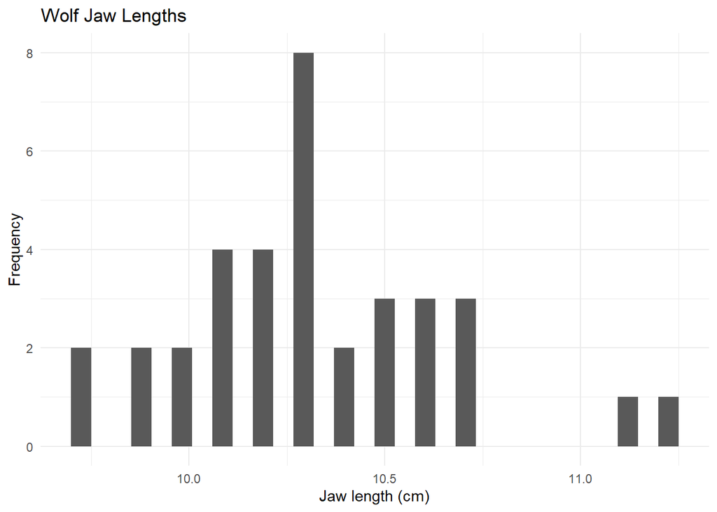

```r
ggplot(data=wolf_jaws) +
  geom_histogram(aes(x=length)) +
  ggtitle('Wolf Jaw Lengths') +
  xlab('Jaw length (cm)') +
  ylab('Frequency') +
  theme_minimal()
```

This does look more or less bell-shaped, although there aren’t that many data points, so it’s a bit of a messy bell.

#### b. What are the sample mean and standard error of the mean for this data set?

```r
jaw_mean <- mean(wolf_jaws$length)
jaw_sterr <- sd(wolf_jaws$length)/sqrt(nrow(wolf_jaws))
```

In this sample, the mean jaw length was **10.3228571 cm** and the standard error was **0.056074 cm**.

#### c. Find the 95% confidence interval for the mean.

We’ll use a t distribution, because the sample size is small. This requires assuming that the sample is a random sample, and that the real distribution is normal (both of which seem like reasonable assumptions here).

```r
spread_95 <- qt(0.975, df=nrow(wolf_jaws)-1) * jaw_sterr

jaw_lower <- jaw_mean - spread_95
jaw_upper <- jaw_mean + spread_95
```

A 95% confidence interval for the true mean jaw length for wolves from this population is:

**10.209 cm $<\mu_{jaw\_length} <$ 10.437 cm**

#### d. Find the 99% confidence interval for the variance.

The confidence interval for the variance is given as:

$$\frac{df s^2}{\chi^2_{\alpha/2,df}} < \sigma^2 < \frac{df s^2}{\chi^2_{1-\alpha/2,df}}$$

assuming that the sample is a random sample, and that the real distribution is normal (both of which seem like reasonable assumptions here).

So, we can find the distribution as:

```r
jaw_df <- nrow(wolf_jaws)-1
jaw_std <- sd(wolf_jaws$length)

jaw_var_lower <- jaw_df*jaw_std^2 / qchisq(0.995, df=jaw_df)
jaw_var_upper <- jaw_df*jaw_std^2 / qchisq(0.005, df=jaw_df)
```

A 99% confidence interval for the true variance in jaw length for wolves from this population is:

**0.063 $cm^2 <\sigma^2_{jaw\_length} <$ 0.227 $cm^2$**

#### e) Find the 99% confidence interval for the standard deviation.

We can get the standard deviation confidence interval by getting the variance interval and taking the square root.

```r
jaw_std_lower <- sqrt(jaw_var_lower)
jaw_std_upper <- sqrt(jaw_var_upper)
```

A 99% confidence interval for the true standard deviation in jaw length for wolves from this population is:

**0.252 cm $<\sigma_{jaw\_length} <$ 0.476 cm**

### 6) Childless Couples

**An analyst is interested in knowing whether the proportion of childless couples in a community deviates significantly from the statewide average of 0.12. A sample of 100 couples is interviewed; the mean proportion of childless couples in the samples is found to be 0.16. Construct the 95% confidence interval around the sample proportion and determine whether the analyst should accept the notion that the “true” proportion could be 0.12.**

```r
couple_sterr <- 1
couple_mean <- 0.16

couple_spread_95 <- qnorm(0.975) * couple_sterr

couple_lower <- couple_mean - couple_spread_95
couple_upper <- couple_mean + couple_spread_95
```

[output not shown]

### 7) Stream Pollutants

**A researcher suspects that the level of a particular stream’s pollutant is higher than the allowable limit of 4.2 mg/l. A sample of n = 17 reveals a mean pollutant level of 6.4 mg/l with a standard deviation of 4.4 mg/l. Is there sufficient evidence that the stream’s pollutant level exceeds the allowable limit? What is the P-value?**

We’ll assume that the actual stream pollutant values being sampled are normally distributed and that the sample is a random one.

```r
couple_sterr <- 4.2/sqrt(17)

pollution_prob <- pt((4.2-6.4)/couple_sterr, df=17)
```

### 8)

**Can death rates be influenced by tax incentives? Kopczuk and Slemrod (2003) investigated this possibility using data on deaths in the US in years in which the government announced it was changing (usually raising) the tax rate on inheritance (the estate tax). The authors calculated the death rate during the 14 days before, and the 14 days after, the changes in the estate tax took effect. The number of deaths per day for each of these periods is given in the following table.**

```r
deaths <- data.frame(year = c(1917, 1917, 1919, 1924, 1926, 1932, 1934, 1935, 1940, 1941, 1942),
                     deaths_high = c(22.21, 18.86, 28.21, 31.64, 18.43, 9.50, 24.29, 26.64, 35.07, 38.86, 28.50),
                     deaths_low = c(24.93, 20.00, 29.93, 30.64, 20.86, 10.14, 28.00, 25.29, 35.00, 37.57, 34.79))

kable(deaths) %>% kable_styling()
```

| year | deaths_high | deaths_low |
| --- | --- | --- |
| 1917 | 22.21 | 24.93 |
| 1917 | 18.86 | 20.00 |
| 1919 | 28.21 | 29.93 |
| 1924 | 31.64 | 30.64 |
| 1926 | 18.43 | 20.86 |
| 1932 | 9.50 | 10.14 |
| 1934 | 24.29 | 28.00 |
| 1935 | 26.64 | 25.29 |
| 1940 | 35.07 | 35.00 |
| 1941 | 38.86 | 37.57 |
| 1942 | 28.50 | 34.79 |

**Use the paired t-test to ask whether the death rate changed significantly after the estate tax rate change.**

#### a) State the null and alternate hypotheses for this analysis.

Ho: There is no significant difference in the death rate during the higher and lower tax rate period immediately around a change in tax rate (mean change is zero).

Ha: There is a significant difference in the death rate during the higher and lower tax rate period immediately around a change in tax rate (mean change is NOT zero).

Assumptions:

1. Both samples are random samples
2. The difference in death rates is normally distributed

These both seem like reasonable assumptions in this context, although it is difficult to assess whether the differences are normal because the sample size is small.

#### b) Why might a paired t-test be an appropriate method to apply to this comparison?

All the data are actually paired, because they occurred immediately before and after the change to tax rate. This helps control for other factors which would impact death rate at different times.

#### c) For each change in the estate tax, calculate the difference in death rate between the higher and lower tax regimes.

```r
deaths$difference <- deaths$deaths_low - deaths$deaths_high
kable(deaths) %>% kable_styling()
```

| year | deaths_high | deaths_low | difference |
| --- | --- | --- | --- |
| 1917 | 22.21 | 24.93 | 2.72 |
| 1917 | 18.86 | 20.00 | 1.14 |
| 1919 | 28.21 | 29.93 | 1.72 |
| 1924 | 31.64 | 30.64 | -1.00 |
| 1926 | 18.43 | 20.86 | 2.43 |
| 1932 | 9.50 | 10.14 | 0.64 |
| 1934 | 24.29 | 28.00 | 3.71 |
| 1935 | 26.64 | 25.29 | -1.35 |
| 1940 | 35.07 | 35.00 | -0.07 |
| 1941 | 38.86 | 37.57 | -1.29 |
| 1942 | 28.50 | 34.79 | 6.29 |

#### d) What is the mean of this difference?

```r
death_diff_mean <- mean(deaths$difference)
```

On average, the death rates under the lower tax rate times exceeded the paired death rates from higher tax rate times by **1.3581818** deaths per day.

#### e) What is the standard deviation of the difference?

```r
death_diff_stdev <- mean(deaths$difference)
```

#### f) What is the sample size?

```r
death_n <- nrow(deaths)
```

The sample size here is **11** - the total number of taxrate switching events.

#### g) What is the standard error of the mean difference?

```r
death_sterr <- death_diff_stdev / sqrt(death_n)
```

#### h) Calculate t for this test.i.How many degrees of freedom will this paired t-statistic have?

```r
death_t <- (death_diff_mean - 0) / death_sterr
```

#### j) What is the critical value for the test, corresponding to $\alpha$= 0.05?

```r
death_t_crit <- qt(0.975, df = death_n-1)
```

The critical value here for $\alpha=0.05$ is **2.2281389**.

#### k) What is the P-value associated with the test statistic, and what is the conclusion from the test?

```r
death_p_val <- 1-pt(death_t, df=death_n-1)
```

[output not shown]

### 9) Colored Dreams

**It was thought that humans dreamed in black and white rather than color. A recent hypothesis is that North Americans did in fact dream in black and white in the era of black-and-white television and movies, but that we shifted back to dream in color media. To test this hypothesis, Murzyn (2008) queried 30 older individuals who had grown up in the black-and-white era and 30 younger individuals who grew up with color media about their dreams. She recorded the percentage of color dreams for each individual. A mean of 68.4% of the younger peoples’ dreams were in color (with standard deviation of 31.8%). On average, 33.9% of the older individuals’ dreams were in color, with a standard deviation of 36.9%. The scores were approximately normally distributed in each group. Is the difference between the two means statistically significant? Use a two-sample t-test for this comparison.**

#### a) State the null and alternate hypotheses for this test.

Ho: There is no difference in the rates at which young and old people dream in color.

Ha: There is a difference in therates at which young and old people dream in color.

#### b) What are the assumptions of a two-sample t-test? Do these data match these assumptions well enough?

1. Both samples are random samples
2. The difference in death rates is normally distributed
3. The standard deviations of both populations is the same

The first one should be a good assumption if the study methodology was designed well. The question states that the second assumption is met, and the third assumption is met based on the small difference in standard deviation values (31.8% and 36.9%) and the reasonably good sample size (30).

#### c) What are the sample variances for each group?

```r
var_old <- .369^2
var_young <- .318^2
```

The variances for the old and young groups are respectively **0.136161** and **0.101124**.

#### d) How many degrees of freedom are associated with each group?

Both groups have **29** degrees of freedom.

#### e) Calculate the pooled variance for these data.

```r
pooled_var_dreams <- ((30-1)*var_old + (30-1)*var_young) / (30+30-2)
```

The pooled variance is **0.1186425**

#### f) Whatis the standard error of the difference between means?

```r
sterr_dreams <- sqrt(pooled_var_dreams*(1/30 + 1/30))
```

The standard error of the difference bewteen means is **0.0889354**.

#### g) Calculate t.

```r
dreams_t <- (.684-.339)/sterr_dreams
```

The t statistic for this test is **3.8792215**.

#### h) How many degrees of freedom does this t-statistic have?

The t statistic has **58** degrees of freedom.

i.What is the critical value of t with $\alpha=0.05$ for this test?

```r
crit_t_dreams <- qt(0.975, df=58)
```

The critical value of t for $\alpha=0.05$ is **2.0017175**.

#### j) What is the most precise P-value that you can determine for this test?

Using scripts there isn’t really an important limitation onestimating p-value precision like there is with a table.

```r
p_val_dreams <- 1-pt(dreams_t, df=58)
```

[output not shown]

#### k) What can you conclude about the difference between the older and younger people in how often they dream in color? Interpret the conclusions of the test in terms of the original scientific question.

Because the p-value we got was tiny, we can reject the null hypothesis. We can assume that there is a significant difference in the rate at which young and old people report dreaming in color. Young people appear to have colored dreams much more often than older people (about twice as often).

### 10) Mosquitoes

**Mosquitoes find their victims in part by odor, so it makes sense to wonder whether what we eat and drink influences our attractiveness to mosquitoes. A study in West Africa (Lefèvre et al., 2010), addressed this question by working with the mosquito species that carry malaria. They wondered whether drinking the local beer influenced attractiveness to mosquitoes. They opened a container holding 50 mosquitoes next to each of 25 alcohol-free participants and measured the proportion of mosquitoes that left the container and flew toward the participants (they called this proportion the “activation”). They repeated this procedure 15 minutes after each of the same participants had consumed a liter of beer and measured the “change in activation” (after minus before). This procedure was also carried out on another 18 human participants who were given water instead of beer. The change in activation of mosquitoes is given for both the beer-and water-drinking groups:**

```r
mosquitoes <- data.frame(treatment = c(rep("beer",25), rep("water",18)),
                        attraction = c(0.36, 0.46, 0.06, 0.18, 0.25, 0.18, -0.06, -0.14, 0.12, 0.39, 0.17, -0.16, -0.05, 0.19, 0.25, 0.31, 0.17, -0.03, 0.23, -0.03, 0.26, 0.30, 0.11, 0.13, 0.21, 0.04, 0, -0.08, -0.12, 0.201, -0.039, 0.10, 0.041, 0.02, 0.236, 0.05, 0.097, 0.122, -0.019, 0.021, -0.08, -0.165, -0.28))
```

#### a) Compare the frequency distributions of the two samples. What trend do you see?

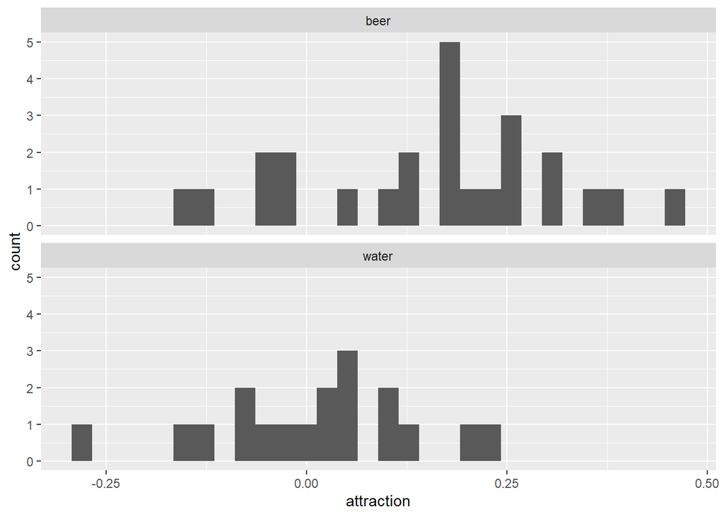

```r
ggplot(data=mosquitoes) +
  geom_histogram(aes(x=attraction)) +
  facet_wrap(~treatment, dir="v")
```

The mean value for the beer drinkers appears to be somewhat higher, although both curves overlap. The spread seems similar across both distributions, both of which seem reasonably normal.

#### b) Test for a difference between the mean changes in mosquito activation between beer-drinking and water-drinking groups.

We’ve just noted that the spread seems similar across both distributions, and that they appear normal. We’ll also need to assume that the human subjects were randomly selected from the population.

Ho: There is no difference in mean activaiton for beer drinkers and water drinkers.

Ha: Mean activation is higher for beer drinkers than for water drinkers.

```r
mosquito_test <- t.test(mosquitoes[mosquitoes$treatment=="beer",]$attraction, mosquitoes[mosquitoes$treatment=="water",]$attraction)
```

Running a t-test with df=40.7072585, we get a t-value of 3.3249969 and a p-value of 0.0018795. Because $\alpha=0.05 >> p$, we can reject the null hypothesis that there is no difference in mean activation between the beer and water drinkers. Beer drinkers exhibited higher mosquito activation than did water drinkers, by on average about 1816.6896552%.

### 11) Ostriches

**Ostriches live in hot environments, and they are normally exposed to the sun for long periods. Mammals in similar environments have special mechanisms for reducing the temperature of their brain relative to their body temperature. Fuller et al. (2003) tested whether ostriches could do the same. The mean body and brain temperature of six ostriches was recorded at typical hot conditions. The results, in degrees Celsius, are as follows:**

```r
ostriches <- data.frame(ostrich = c(1,2,3,4,5,6),
                        body_temp = c(38.51, 38.45, 38.27, 38.52, 38.62, 38.18),
                        brain_temp = c(39.32, 39.21, 39.20, 38.68, 39.09, 38.94))
ostriches$difference <- ostriches$brain_temp - ostriches$body_temp

kable(ostriches) %>% kable_styling()
```

| ostrich | body_temp | brain_temp | difference |
| --- | --- | --- | --- |
| 1 | 38.51 | 39.32 | 0.81 |
| 2 | 38.45 | 39.21 | 0.76 |
| 3 | 38.27 | 39.20 | 0.93 |
| 4 | 38.52 | 38.68 | 0.16 |
| 5 | 38.62 | 39.09 | 0.47 |
| 6 | 38.18 | 38.94 | 0.76 |

#### a) Test for a mean difference in temperature between body and brain for these ostriches.

We can run a paired test because each ostrich has one body and one brian. We’ll need to assume that the human subjects were randomly selected from the population and that the mean temperature difference is normally distributed across ostriches.

Ho: There is no difference in mean body and brain temperature in ostriches.

Ha: There is a difference in mean body and brain temperature in ostriches.

```r
ostrich_test <- t.test(ostriches$difference)
```

Running a t-test with df=5, we get a t-value of 5.6099416 and a p-value of 0.0024887. Because $\alpha=0.05 >> p$, we can reject the null hypothesis that there is no difference in mean temperature in ostrich brains and bodies. Brain temperatures tend to be higher by on average about 0.6483333 degrees C.

#### b) Compare the results to the prediction made from mammals in similar environments.

Ostrich brains actually seem to be higher than their body temperatures, in contrast to their mammalian friends. This doesn’t mean that ostriches don’t have adaptations to cool their brains, though. Brains consume a large amount of metabolic energy and produce meaningful amounts of heat, so it could also be that ostriches are just supergeniuses that devote enormous metabolic energy to their brains.

### 12) Household Child Rates

**The mean number of children among a sample of 15 low-income households is 2.8. The mean number of children among a sample of 19 high-income households is 2.4. The standard deviations for low-and high-income households are found to be 1.6 and 1.7, respectively. Test the hypothesis of no difference against the alternative that high-income households have fewer children. Use a pooled estimate of the variance.**

We’ll run an independent two-sample t-test. We’ll need to assume that the households were randomly selected from the population and that the mean number of children difference is normally distributed across households. We’ll also assume that the population variances are the same in both income groups (which enables us to estimate the pooled variance).

Ho: There is no difference in mean number of children between low and high income households.

Ha: High income households have fewer children.

```r
children_pooled_var <- ((15-1)*1.6^2 + (19-1)*1.7^2)/(15+19-2)
children_t <- (2.8-2.4)/(children_pooled_var*sqrt(1/15+1/19))

children_p <- 1-pt(children_t, df=(15+19-2))
```

We found a pooled variance of 2.745625. Running a t-test with df=32, we get a t-value of 0.4217953 and a p-value of 0.3379973. Because $\alpha=0.05 < p$, we cannot reject the null hypothesis that there is no difference in the number of mean children between low-income and high-income households.

### 13) Recycling Paper

**Recycling paper has some obvious benefits, but it may have unintended consequences. For example, perhaps people are less careful about how much paper they use if they know that their waste will be recycled. Catlin and Wang (2013) tested this idea by measuring paper use in two groups of experimental participants. Each person was placed in a room alone with scissors, paper, and a trash can, and was told that he or she was testing the scissors. In the “recycling” group only, there was also a recycling bin in the room. The amount of paper used by each participant was measured in grams. The data from each person are listed below.**

```r
no_bin <- c(4, 4, 4, 4, 4, 4, 4, 5, 8, 9, 9, 9, 9, 12, 12, 13, 14, 14, 14, 14, 15, 23)
bin <- c(4, 5, 8, 8, 8, 9, 9, 9, 12, 14, 14, 15, 16, 19, 23, 28, 40, 43, 129, 130)

paper <- data.frame(treatment = c(rep("no_bin", length(no_bin)),rep("bin", length(bin))),
                    paper = c(no_bin,bin))
```

#### a) Make and examine histograms of these data. Are the frequency distributions of paper use in the two treatment groups similar in shape and spread?

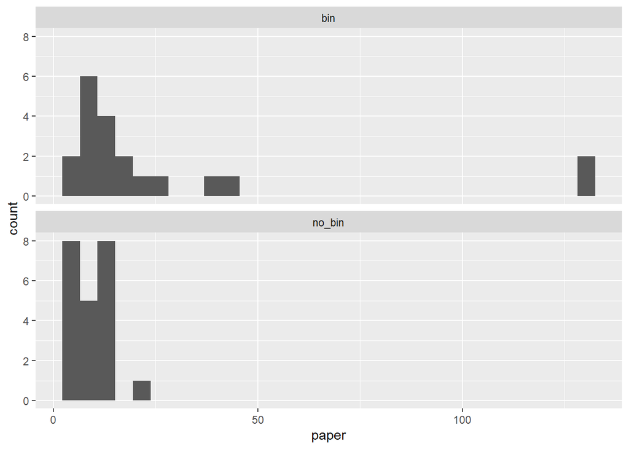

```r
ggplot(data=paper) +
  geom_histogram(aes(x=paper)) +
  facet_wrap(~treatment, dir="v")
```

#### b) Based on your results in part a, discuss your options for testing a difference between these two groups in the amount of paper used.

Because the distributions aren’t normal and have apparently different variances, it would be difficult to use a parametric test like the t-test. We could use a rank-based test instead, though, which have less stringent assumptions.

#### c) Apply a Mann-Whitney U-test to test the hypothesis that these two treatments have the same distribution of paper use. State the nulland alternative hypotheses clearly.

Ho: There is no difference in the frequency distribution of paper usage in the two groups.

Ha: There is a difference in the frequency distribution of paper usage in the two groups.

#### d) Rank all the values of paper use from smallest to largest. Properly account for ties.

```r
paper$ranks <- rank(paper$paper)

kable(paper) %>% kable_styling()
```

| treatment | paper | ranks |
| --- | --- | --- |
| no_bin | 4 | 4.5 |
| no_bin | 4 | 4.5 |
| no_bin | 4 | 4.5 |
| no_bin | 4 | 4.5 |
| no_bin | 4 | 4.5 |
| no_bin | 4 | 4.5 |
| no_bin | 4 | 4.5 |
| no_bin | 5 | 9.5 |
| no_bin | 8 | 12.5 |
| no_bin | 9 | 18.0 |
| no_bin | 9 | 18.0 |
| no_bin | 9 | 18.0 |
| no_bin | 9 | 18.0 |
| no_bin | 12 | 23.0 |
| no_bin | 12 | 23.0 |
| no_bin | 13 | 25.0 |
| no_bin | 14 | 28.5 |
| no_bin | 14 | 28.5 |
| no_bin | 14 | 28.5 |
| no_bin | 14 | 28.5 |
| no_bin | 15 | 32.5 |
| no_bin | 23 | 36.5 |
| bin | 4 | 4.5 |
| bin | 5 | 9.5 |
| bin | 8 | 12.5 |
| bin | 8 | 12.5 |
| bin | 8 | 12.5 |
| bin | 9 | 18.0 |
| bin | 9 | 18.0 |
| bin | 9 | 18.0 |
| bin | 12 | 23.0 |
| bin | 14 | 28.5 |
| bin | 14 | 28.5 |
| bin | 15 | 32.5 |
| bin | 16 | 34.0 |
| bin | 19 | 35.0 |
| bin | 23 | 36.5 |
| bin | 28 | 38.0 |
| bin | 40 | 39.0 |
| bin | 43 | 40.0 |
| bin | 129 | 41.0 |
| bin | 130 | 42.0 |

#### e) For each treatment group, calculate the rank sum and the sample size.

```r
r_bin <- sum(paper[paper$treatment=="bin",]$rank)
r_nobin <- sum(paper[paper$treatment=="no_bin",]$rank)
n_bin <- nrow(paper[paper$treatment=="bin",])
n_nobin <- nrow(paper[paper$treatment=="no_bin",])
```

The rank sum and sample size for the bin group are **523.5** and **20**. The rank sum and sample size for the no-bin group are **379.5** and **22**.

#### f) Calculate the Mann-Whitney U1value for the treatment without the recycling bin.

```r
U_nobin <- n_bin*n_nobin + (n_nobin*(n_nobin+1))/2 - r_nobin
```

The U1 value for the no-bin treatment is **313.5**.

#### g) Using the result from part f, calculate U2for the treatment with the recycling bin.h.What is the value of test statistic U?

```r
U_bin <- n_bin*n_nobin - U_nobin
```

The U2 value for the bin treatment is **126.5**.

#### i) Calculate P-value as accurately as you can, state the conclusion of the test, and interpret the results.

We can find the p-value for a given U statistic as:

```r
pwilcox(max(U_bin,U_nobin), n_bin, n_nobin, lower.tail=F)
```

```
## [1] 0.008697759
```

Because our p-value is much smaller than $\alpha=0.05$, we can reject the null hypothesis that the frequency distributions of the paper usage between recycling and non-recycling bin groups. The median value of paper use for the group with a recycling bin was significantly higher.

### 14 Mosquitoes Again

**The distribution of body size of mosquitoes (as measured by weight) is known to be log-normal. The (untransformed) weights of 11 female and nine male mosquitoes are given below in milligrams. Do the two sexes weigh the same on average?**

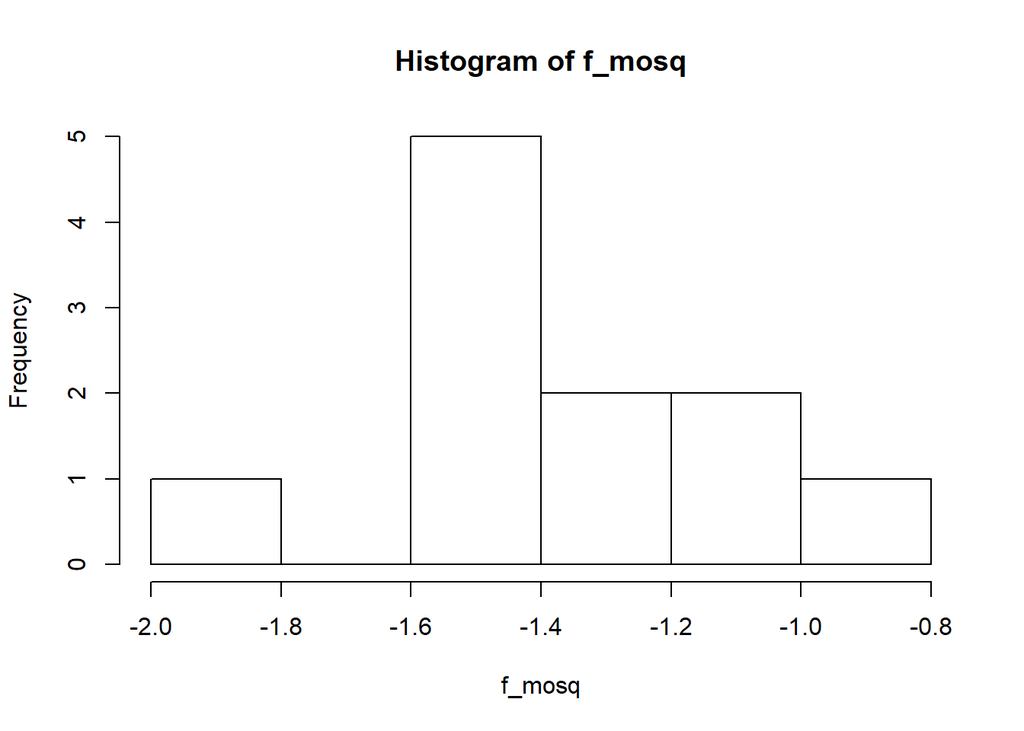

```r
f_mosq <- log(c(0.291, 0.208, 0.241, 0.437, 0.228, 0.256, 0.208, 0.234, 0.320, 0.340, 0.150))
m_mosq <- log(c(0.185, 0.222, 0.149, 0.187, 0.191, 0.219, 0.132, 0.144, 0.140))

hist(f_mosq)
```

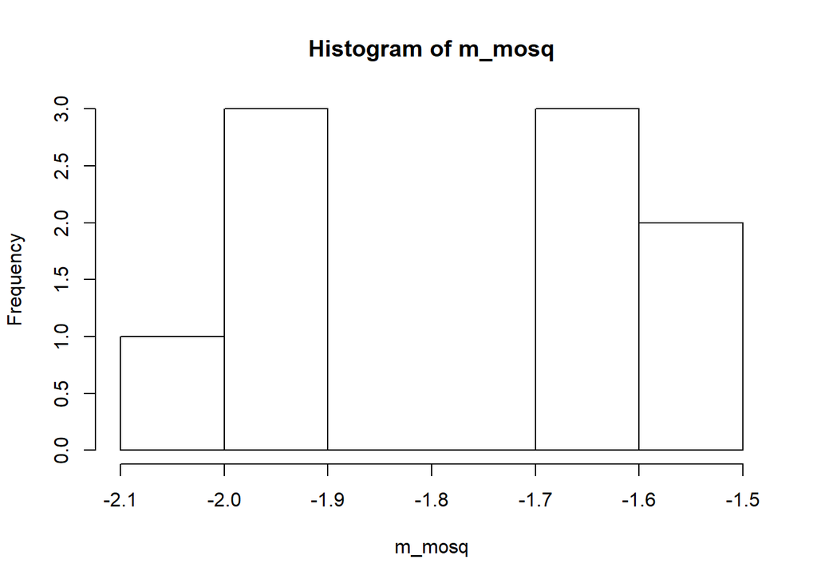

```r
hist(m_mosq)
```

```r
sd(f_mosq)
```

```
## [1] 0.2880295
```

```r
sd(m_mosq)
```

```
## [1] 0.1972447
```

We’ll ignore the fact that the male distribution doesn’t look normal (it seems bimodal, maybe just by chance with the small sample size) because the question states that the population distribution is normal. The variances don’t differ hugely either, and we’ll assume that the mosquitoes used are a random sample of the population. We’ll run an unpaired t-test to check whether the means differ:

Ho: There is no difference in mean mass between male and female mosquitoes.

Ha: There is a difference in mean mass between male and female mosquitoes.

```r
mosquito_test <- t.test(f_mosq, m_mosq)
```